# 1.1.6. Principal Component Analysis

차원축소는 매우 많은 피처로 구성된 다차원 데이터 세트의 차원을 축소해 새로운 차원의 데이터 세트를 생성하는 것입니다.  
일반적으로 차원이 증가할수록 데이터 포인트 간의 거리가 기하급수적으로 멀어지게 되고 희소(sparse)한 구조를 가지게 됩니다.  
수백 개 이상의 피처로 구성된 데이터 세트의 경우 상대적으로 적은 차원에서 학습된 모델보다 예측 신뢰도가 떨어집니다.  
또한 피처가 많을 경우 개별 피처간에 상관관계가 높을 가능성이 큽니다. 이 경우 선형 모델에서는 입력 변수 간의 상관관계가 높을 경우 다중 공선성 문제로 예측 성능이 저하됩니다.

다차원의 피처를 차원 축소해 피처 수를 줄이면 더 직관적으로 데이터를 해석할 수 있습니다.  
예를 들어 수십 개 이상의 피처가 있는 데이터의 경우 이를 시각적으로 표현해 데이터의 특성을 파악하기는 불가능 합니다.  
이 경우 3차원 이하의 차원 축소를 통해서 시각적으로 데이터를 압축해서 표현할 수 있습니다.

일반적으로 차원 축소는 피처 선택(feature selection)과 피처 추출(feature extraction)로 나눌 수 있습니다.  
피처 선택, 즉 특성 선택은 말 그대로 특정 피처에 종속성이 강한 불필요한 피처는 아예 제거하는 것 입니다.  
피처 추출은 기존 피처를 저차원의 중요 피처로 압축해서 추출하는 것입니다.  
이렇게 새롭게 추출된 특성은 기존의 피처가 압축된 것이므로 기존의 피처와는 완전히 다른 값이 됩니다.

피처 추출은 기존 피처를 단순 압축이 아닌, 피처를 함축적으로 더 잘 설명할 수 있는 또 다른 공간으로 매핑해 추출하는 것입니다.  
가령 학생을 평가하는 다양한 요소로 모의고사 성적, 내신 성적, 수능 성적, 봉사활동, 대외활동, 수상경력 등과 관련된 여러가지 피처로 돼있는 데이터 세트라면  
이를 학업 성취도, 커뮤니케이션 능력, 문제 해결력과 같은 더 함축적인 요약 특성으로 추출할 수 있습니다.  
이러한 함축적인 특성 추출은 기존 피처가 전혀 인지하기 어려웠던 잠재적인 요소(Latent Factor)를 추출하는 것을 의미 합니다.

PCA(Principal Component Analysis)는 가장 대표적인 차원축소 기법 입니다.  
PCA는 여러 변수간에 존재하는 상관관계를 이용해 이를 대표하는 주성분(Principal Component)을 추출해 차원을 축소하는 기법입니다.  
PCA로 차원을 축소할 때는 기존 데이터의 정보 유실이 최소화되는 것이 당연합니다.  
이를 위해서 PCA는 가장 높은 변동성을 가지는 데이터의 축을 찾아 이 축으로 차원을 축소하는데, 이것이 PCA의 주성분이 됩니다.(즉, 변동성이 크면 데이터의 특성을 가장 잘 나타내는 것으로 간주합니다.)

## Example)

- 사람의 키와 몸무게에 대한 임의의 데이터
  - 참조 : https://ddongwon.tistory.com/114

[figure not shown]

1. 각 축에 대한 평균값을 구한 뒤, 해당 점이 원점이 되도록 평행이동

[figure not shown]

1. 데이터에서 원점을 지나는 직선에 수선의 발을 내려 해당 길이가 최대가 되는 직선을 찾는다.
   - 원점에서 수선의 발까지 길이의 제곱합이 변동성이 된다.

[figure not shown]

https://angeloyeo.github.io/2019/07/27/PCA.html

1. 찾은 직선을 PC1으로 설정하고, loading score를 구한다.

[figure not shown]

1. PC1에 직교하는 직선을 PC2로 잡는다.

[figure not shown]

1. 추출된 피처(PC1, PC2)가 전체 데이터의 특징을 얼마나 잘 설명하는지 수치로 확인한다.

[figure not shown]

1. PC2 축을 제거하고 PC1 축만을 가지고 데이터를 1차원으로 나타낸다.

[figure not shown]

- 3차원 데이터

[figure not shown]

# Example) Iris Data Set

[figure not shown]

sepal : 꽃 받침 petal : 꽃 잎

```python
from sklearn.datasets import load_iris
import pandas as pd
import matplotlib.pyplot as plt
plt.rcParams["figure.figsize"] = (10, 10)

iris = load_iris()

columns=['sepal_length', 'sepal_width', 'petal_length', 'petal_width']
irisDF = pd.DataFrame(iris.data, columns = columns)
irisDF['target'] = iris.target
irisDF.head()
```

|  | sepal_length | sepal_width | petal_length | petal_width | target |
| --- | --- | --- | --- | --- | --- |
| 0 | 5.1 | 3.5 | 1.4 | 0.2 | 0 |
| 1 | 4.9 | 3.0 | 1.4 | 0.2 | 0 |
| 2 | 4.7 | 3.2 | 1.3 | 0.2 | 0 |
| 3 | 4.6 | 3.1 | 1.5 | 0.2 | 0 |
| 4 | 5.0 | 3.6 | 1.4 | 0.2 | 0 |

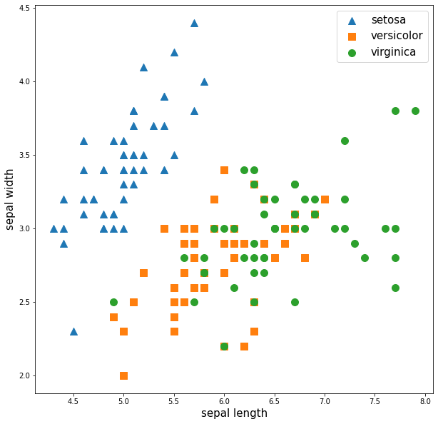

```python
# setosa는 세모, versicolor는 네모, virginica는 동그라미로 표현
markers = ['^', 's', 'o']

# setosa의 target 값은 0, versicolor는 1, virginica는 2, 각 target별로 다른 모양으로 산점도로 표시
for i, marker in enumerate(markers):
    x_axis_data = irisDF[irisDF['target'] == i]['sepal_length']
    y_axis_data = irisDF[irisDF['target'] == i]['sepal_width']
    plt.scatter(x_axis_data, y_axis_data, marker = marker, s=100, label=iris.target_names[i])


plt.legend(fontsize = 15)
plt.xlabel('sepal length', fontsize = 15)
plt.ylabel('sepal width', fontsize = 15)
plt.show()
```

- scaling

```python
from sklearn.preprocessing import StandardScaler

# Target 값을 제외한 모든 속성 값을 StandardScaler를 이용해 표준 정규 분포를 가지는 값들로 변환
iris_scaled = StandardScaler().fit_transform(irisDF.iloc[:, :-1])
```

- PCA

```python
from sklearn.decomposition import PCA

pca = PCA(n_components = 2)

# fit()과 transform()을 호출해 PCA 변환 데이터 반환
pca.fit(iris_scaled)
iris_pca = pca.transform(iris_scaled)
print(iris_pca.shape)
```

```
(150, 2)
```

```python
# PCA 변환된 데이터의 컬럼 명을 각각 pca_component_1, pca_component_2로 명명
pca_columns = ['pca_component_1', 'pca_component_2']
irisDF_pca = pd.DataFrame(iris_pca, columns = pca_columns)
irisDF_pca['target'] = iris.target
irisDF_pca.head()
```

|  | pca_component_1 | pca_component_2 | target |
| --- | --- | --- | --- |
| 0 | -2.264703 | 0.480027 | 0 |
| 1 | -2.080961 | -0.674134 | 0 |
| 2 | -2.364229 | -0.341908 | 0 |
| 3 | -2.299384 | -0.597395 | 0 |
| 4 | -2.389842 | 0.646835 | 0 |

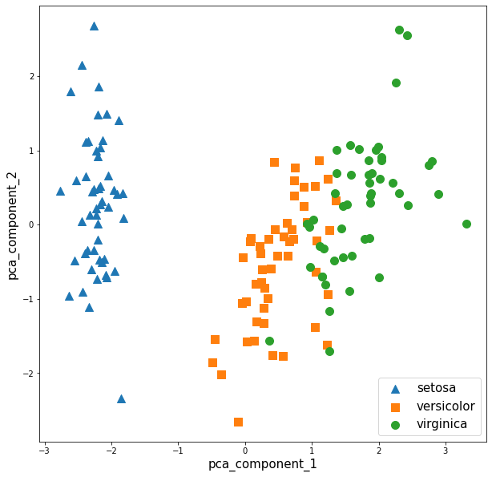

```python
# setosa는 세모, versicolor는 네모, virginica는 동그라미로 표현
markers = ['^', 's', 'o']

# pca_component_1을 x축, pca_component_2를 y축으로 scatter plot 수행
for i, marker in enumerate(markers):
    x_axis_data = irisDF_pca[irisDF_pca['target'] == i]['pca_component_1']
    y_axis_data = irisDF_pca[irisDF_pca['target'] == i]['pca_component_2']
    plt.scatter(x_axis_data, y_axis_data, marker = marker, s=100, label=iris.target_names[i])


plt.legend(fontsize = 15)
plt.xlabel('pca_component_1', fontsize = 15)
plt.ylabel('pca_component_2', fontsize = 15)
plt.show()
```

```python
print(pca.explained_variance_ratio_)
```

```
[0.72962445 0.22850762]
```

- boston

```python
import warnings

warnings.filterwarnings('ignore')

import numpy as np
import matplotlib.pyplot as plt
import pandas as pd
import seaborn as sns

from sklearn.datasets import load_boston
from sklearn.model_selection import train_test_split
from sklearn.linear_model import LinearRegression, Ridge, Lasso, ElasticNet
from sklearn.metrics import mean_squared_error, r2_score

boston = load_boston()

bostonDF = pd.DataFrame(boston.data, columns = boston.feature_names)

bostonDF['PRICE'] = boston.target
```

```python
boston_scaled = StandardScaler().fit_transform(bostonDF.iloc[:, :-1])
```

```python
pca = PCA()

pca.fit(boston_scaled)
boston_pca = pca.transform(boston_scaled)
print(boston_pca.shape)
```

```
(506, 13)
```

```python
pca_columns = ['comp1', 'comp2', 'comp3', 'comp4', 'comp5', 'comp6', 'comp7', 'comp8', 'comp9', 'comp10', 'comp11', 'comp12', 'comp13']
bostonDF_pca = pd.DataFrame(boston_pca, columns=pca_columns)
bostonDF_pca['PRICE'] = boston.target
bostonDF_pca.head()
```

|  | comp1 | comp2 | comp3 | comp4 | comp5 | comp6 | comp7 | comp8 | comp9 | comp10 | comp11 | comp12 | comp13 | PRICE |
| --- | --- | --- | --- | --- | --- | --- | --- | --- | --- | --- | --- | --- | --- | --- |
| 0 | -2.098297 | 0.773113 | 0.342943 | -0.891774 | 0.423070 | -0.315338 | 0.318641 | 0.295832 | -0.424937 | 0.640206 | -0.033000 | 0.019440 | 0.365975 | 24.0 |
| 1 | -1.457252 | 0.591985 | -0.695199 | -0.487459 | -0.195876 | 0.264223 | 0.553861 | -0.223670 | -0.166962 | 0.084236 | -0.640810 | -0.125797 | -0.070719 | 21.6 |
| 2 | -2.074598 | 0.599639 | 0.167122 | -0.739204 | -0.934534 | 0.448095 | 0.484560 | 0.105166 | 0.069775 | -0.180380 | -0.487557 | 0.133327 | -0.014022 | 34.7 |
| 3 | -2.611504 | -0.006871 | -0.100284 | -0.343721 | -1.104956 | 0.664649 | 0.622641 | 0.255941 | -0.342246 | 0.045901 | -0.360209 | 0.508678 | 0.007847 | 33.4 |
| 4 | -2.458185 | 0.097712 | -0.075348 | -0.427907 | -1.065924 | 0.617047 | 0.705086 | -0.134524 | -0.417668 | -0.140880 | -0.395150 | 0.497732 | 0.014274 | 36.2 |

```python
print(pca.explained_variance_ratio_)
```

```
[0.47129606 0.11025193 0.0955859  0.06596732 0.06421661 0.05056978
 0.04118124 0.03046902 0.02130333 0.01694137 0.0143088  0.01302331
 0.00488533]
```

```python
sum(pca.explained_variance_ratio_[:5])
```

```
0.8073178205045912
```

```python
from sklearn.model_selection import cross_val_score

lr = LinearRegression()
scores = cross_val_score(lr, bostonDF.iloc[:, :-1], bostonDF.iloc[:, -1], scoring='neg_mean_squared_error', cv=3)
rmse_scores = np.sqrt(-1 * scores)
print('평균정확도 : ', np.mean(rmse_scores))
```

```
평균정확도 :  10.557555207835309
```

```python
from sklearn.model_selection import cross_val_score

pca_X = bostonDF_pca[['comp1', 'comp2', 'comp3', 'comp4', 'comp5', 'comp6']]

lr = LinearRegression()
scores = cross_val_score(lr, pca_X, bostonDF['PRICE'], scoring='neg_mean_squared_error', cv=3)
rmse_scores = np.sqrt(-1 * scores)
print('평균정확도 : ', np.mean(rmse_scores))
```

```
평균정확도 :  5.5534638609071765
```

```python
X_train, X_test, y_train, y_test = train_test_split(pca_X, bostonDF['PRICE'], test_size = 0.3, shuffle=True)

print(X_train.shape, X_test.shape, y_train.shape, y_test.shape)
```

```
(354, 6) (152, 6) (354,) (152,)
```

```python
model = LinearRegression()

model.fit(X_train, y_train)

model.score(X_test, y_test)
```

```
0.8033494393874334
```